# Flight Data Explorative Analysis - Coronavirus

## Preliminary Wrangling

This year we saw the advent of the Coronavirus outbreak and pandemic. As of July, new daily cases are still rising here in the United States and travel restrictions, whether they be government mandated or self imposed by the population, are changing the demand for airline travel.

#### Note about data Collected

The interface on the Bureau of Transportation and Statistics allows for users to manually download sets of flight data from its [website](https://www.transtats.bts.gov/DL_SelectFields.asp?Table_ID=236). For this analysis we will be sticking with 2 months worth of data, specifically the periods of **April 2019** and **April 2020**. I wish to see if there are any significant trends in Airline usage or performance during the Cronovirus pandemic.

```python
# import all packages and set plots to be embedded inline
import numpy as np
import pandas as pd
import matplotlib.pyplot as plt
import seaborn as sb
import gc
import os

%matplotlib inline

# suppress warnings from final output
import warnings
warnings.simplefilter("ignore")
```

```python
#create dataframes
apr19 = pd.read_csv('Data/Apr2019_flights.csv')
apr20 = pd.read_csv('Data/Apr2020_flights.csv')
```

```python
#create master dataframe
frames = [apr19, apr20]
flights = pd.concat(frames)
```

```python
flights['YEAR'].value_counts()
flights.head()
```

|  | YEAR | MONTH | DAY_OF_MONTH | DAY_OF_WEEK | FL_DATE | OP_UNIQUE_CARRIER | TAIL_NUM | OP_CARRIER_FL_NUM | ORIGIN_AIRPORT_ID | ORIGIN | ... | CANCELLATION_CODE | DIVERTED | CRS_ELAPSED_TIME | ACTUAL_ELAPSED_TIME | CARRIER_DELAY | WEATHER_DELAY | NAS_DELAY | SECURITY_DELAY | LATE_AIRCRAFT_DELAY | Unnamed: 35 |
| --- | --- | --- | --- | --- | --- | --- | --- | --- | --- | --- | --- | --- | --- | --- | --- | --- | --- | --- | --- | --- | --- |
| 0 | 2019 | 4 | 5 | 5 | 2019-04-05 | NK | N646NK | 779 | 12953 | LGA | ... | NaN | 0.0 | 188.0 | 181.0 | NaN | NaN | NaN | NaN | NaN | NaN |
| 1 | 2019 | 4 | 6 | 6 | 2019-04-06 | NK | N615NK | 779 | 12953 | LGA | ... | NaN | 0.0 | 188.0 | 173.0 | NaN | NaN | NaN | NaN | NaN | NaN |
| 2 | 2019 | 4 | 7 | 7 | 2019-04-07 | NK | N633NK | 779 | 12953 | LGA | ... | NaN | 0.0 | 188.0 | 182.0 | NaN | NaN | NaN | NaN | NaN | NaN |
| 3 | 2019 | 4 | 8 | 1 | 2019-04-08 | NK | N655NK | 779 | 12953 | LGA | ... | NaN | 0.0 | 188.0 | 225.0 | 0.0 | 0.0 | 47.0 | 0.0 | 0.0 | NaN |
| 4 | 2019 | 4 | 9 | 2 | 2019-04-09 | NK | N605NK | 779 | 12953 | LGA | ... | NaN | 0.0 | 188.0 | 207.0 | 0.0 | 0.0 | 85.0 | 0.0 | 0.0 | NaN |

5 rows × 36 columns

```python
flights.info()
```

```
<class 'pandas.core.frame.DataFrame'>
Int64Index: 925405 entries, 0 to 313381
Data columns (total 36 columns):
 #   Column               Non-Null Count   Dtype
---  ------               --------------   -----
 0   YEAR                 925405 non-null  int64
 1   MONTH                925405 non-null  int64
 2   DAY_OF_MONTH         925405 non-null  int64
 3   DAY_OF_WEEK          925405 non-null  int64
 4   FL_DATE              925405 non-null  object
 5   OP_UNIQUE_CARRIER    925405 non-null  object
 6   TAIL_NUM             832733 non-null  object
 7   OP_CARRIER_FL_NUM    925405 non-null  int64
 8   ORIGIN_AIRPORT_ID    925405 non-null  int64
 9   ORIGIN               925405 non-null  object
```

[output cut: 28 more lines]

### What is the structure of your dataset?

This dataset is a single table that is composed of individual flight statistics reported to the Bureau of Transportation of the United States. This includes attributes such as time of take of and landing, point of origin, delay, etc.

Structure is 925,405 observations with 35 separate attributes. 1 extra column will be removed as it is unnamed. There are many numeric based values related to time or duration. There are also categorical values related to identifiying point of origin, destination, flight, and carrier.

More details on columns and their values can be found [HERE](https://www.transtats.bts.gov/DL_SelectFields.asp?Table_ID=236)

### What is/are the main feature(s) of interest in your dataset?

In this dataset, I am primarily interested to see if the Coronavirus pandemic significantly affected flight trafic performance and quantity. This will mostly be tied to operational efficiency and delays.

### What features in the dataset do you think will help support your investigation into your feature(s) of interest?

Starting off, roughly count will be a good high level indicator. After that moving into specifics for certain states that may have been hit harder. It is also possible, that if there are less people traveling, there will be less delays caused by passengers, such as security issues.

## Univariate Exploration

Let's begin with checking the change in overall flight count between April 2019 and April 2020.

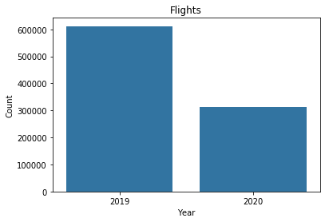

```python
default_color = sb.color_palette()[0]
sb.countplot(data = flights, x = 'YEAR', color = default_color,);
plt.xlabel('Year')
plt.ylabel('Count');
plt.title('Flights');
```

```python
print(flights['YEAR'].value_counts())
print('\nApril 2020 had only ' + str(np.round(313382/612023, 2)*100) + '% of the flights from the previous year')
```

```
2019    612023
2020    313382
Name: YEAR, dtype: int64

April 2020 had only 51.0% of the flights from the previous year
```

Right off the bat, we can see a decrease between 2019 and 2020. April 2020 had only 51.0% of the flights from the previous year. Social Distancing and concern over public health definitely seems to have had an immeadiate effect.Next to get an idea of which states are most active flyers, lets rank for both years together.

```python
#set alphabetical ordering to states
states = flights.ORIGIN_STATE_ABR.unique()
level_order = sorted(states)
ordered_states = pd.api.types.CategoricalDtype(ordered = True, categories = level_order)
flights['ORIGIN_STATE_ABR'] = flights['ORIGIN_STATE_ABR'].astype(ordered_states)
apr19['ORIGIN_STATE_ABR'] = apr19['ORIGIN_STATE_ABR'].astype(ordered_states)
apr20['ORIGIN_STATE_ABR'] = apr20['ORIGIN_STATE_ABR'].astype(ordered_states)
```

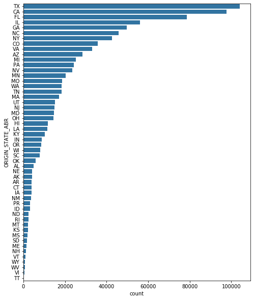

```python
plt.figure(figsize=[8, 10])
order_states = flights['ORIGIN_STATE_ABR'].value_counts().index
sb.countplot(data = flights, y = 'ORIGIN_STATE_ABR', color = default_color, order = order_states);
```

This mostly makes sense with population sizes for these states, but there are some interesting cases. NY for example is below Georgia and North Carloina in this chart and they both have half the population size. We will revisit this later on. This is made up of total flights for both 2019 and 2020.

Next let's see if flights per day changed over the course of April 2020

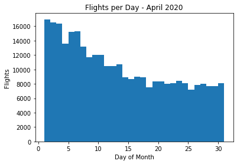

```python
#2020
bins = np.arange(1, 31+1, 1)
plt.hist(apr20['DAY_OF_MONTH'], bins = bins);
plt.title('Flights per Day - April 2020');
plt.xlabel('Day of Month')
plt.ylabel('Flights');
```

Here we see the number of flights declines by around 50% over just the course of April 2020. For the United States, social distancing guidelines were initially established in March, but then extended at the end of the month. As the situation got more severe, more people decided traveling was not worth the risk. Lets look at this same info but for 2019.

[figure not shown]

```python
#2019
bins = np.arange(1, 31+1, 1)
plt.hist(apr19['DAY_OF_MONTH'], bins = bins);
plt.title('Flights per Day - April 2020');
plt.xlabel('Day of Month')
plt.ylabel('Flights');
```

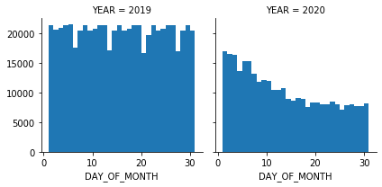

```python
#bins = np.arange(0, 2079+10, 10)
bins = np.arange(1, 31+1, 1)
g = sb.FacetGrid(data = flights, col = 'YEAR')
g.map(plt.hist, "DAY_OF_MONTH",bins = bins)
#plt.xlim(0,500)
```

### Discuss the distribution(s) of your variable(s) of interest. Were there any unusual points? Did you need to perform any transformations?

The Flights per Day graphs for 2019 and 2020 were the most telling as they showed the dramtic change in flights over such a short amount of time.

No transformations were needed for any graphs.

### Of the features you investigated, were there any unusual distributions? Did you perform any operations on the data to tidy, adjust, or change the form of the data? If so, why did you do this?

Thankfully this dataset is already pretty clean and neat, so no real modifications needed (at this point at least).

Only change was that `ORIGIN_STATE_ABR` became ordered alphabetically.

## Bivariate Exploration

Let's start by seeing the change in total flights by state between April 2019 and April 2020.

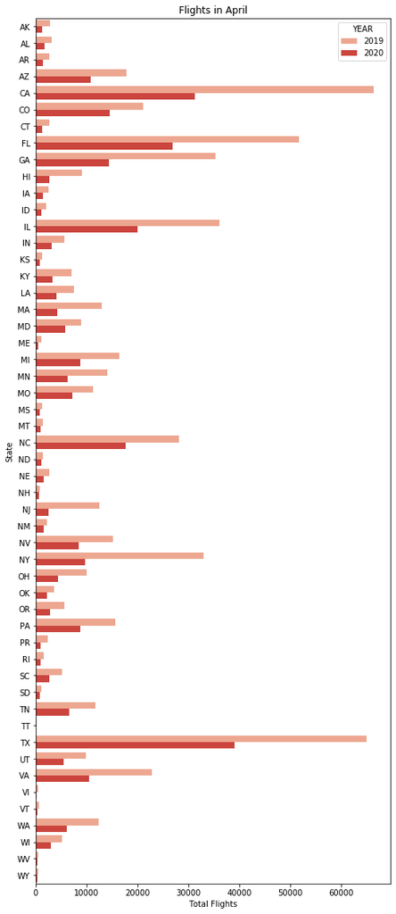

```python
#Graph comparing 2019 to 2020 for each state

plt.figure(figsize = [8,20])
sb.countplot(data = flights, y = 'ORIGIN_STATE_ABR', color = default_color, hue = 'YEAR', palette = 'Reds');
plt.xlabel('Total Flights')
plt.ylabel('State')
plt.title('Flights in April');
```

In this graph we see states listed by amount of flights departing. Notice the sharp drop across the board, especially in the most populous states.

New York is an interesting case both in 2019 and 2020. NY has a population estimated as of July 2019 of 19,453,561, which ranks it Number 4 in the United States, however it was ranked 6th in departing flights behind Georgia which has roughly half the population. In 2020, NY dropped its flight counts significantly, most likely due to it being the initial outbreak hot spot in the US.

New Jersey also had an incredibly sharp drop.

Now lets see if there are any relationships in our data.

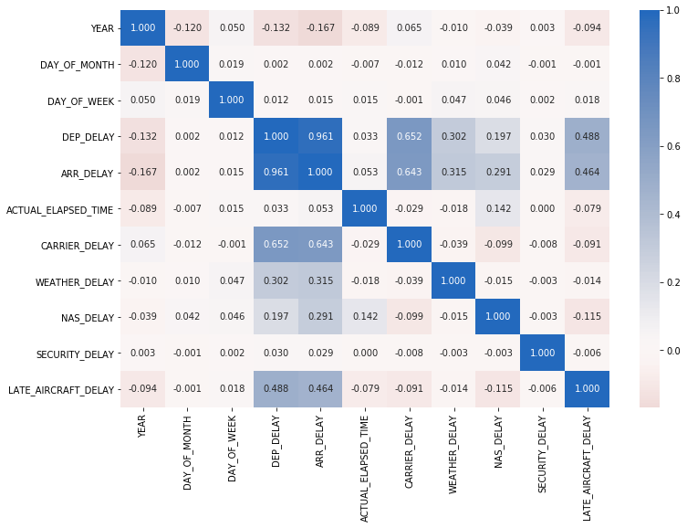

```python
#Correlations using the combined 2019 and 2020 data

numeric_vars = ['YEAR','DAY_OF_MONTH', 'DAY_OF_WEEK', 'DEP_DELAY',
                'ARR_DELAY','ACTUAL_ELAPSED_TIME',
                'CARRIER_DELAY', 'WEATHER_DELAY', 'NAS_DELAY', 'SECURITY_DELAY', 'LATE_AIRCRAFT_DELAY']

plt.figure(figsize = [12, 8])
sb.heatmap(flights[numeric_vars].corr(), annot = True, fmt = '.3f',cmap = 'vlag_r', center = 0)
plt.show()
```

Ok first let's discuss positive correlations. Kind of self explanatory but departure and arrival delays are heavily correlated. This would makes as a departure delay would be very difficult to compensate for mid flight. Also, the delay categories Carrier, Weather, National Air Service, and Late Aircraft are all positively correlated with departure and arival time but Security Delay is neutral. We may want to take a look at this later on.

For negative correlations, we can see the affect of the overall decrease observed earlier between `YEAR` and `DAY_OF_MONTH`. Interestingly, there is also a negative correlation between delay values and the year. Maybe the decrease of volume has eased up on general pressure allowing flights to operate more smoothly.

Let's take a closer look at delay values by year.

```python
flights.DEP_DELAY.describe()
```

```
count    781262.000000
mean          7.376025
std          44.563975
min         -73.000000
25%          -7.000000
50%          -3.000000
75%           2.000000
max        2079.000000
Name: DEP_DELAY, dtype: float64
```

```python
#comparison of amount of flights delayed by 30 minutes or more
bins = np.arange(0, 2079+10, 10)
g = sb.FacetGrid(data = flights[flights['DEP_DELAY'] >= 30], col = 'YEAR')
g.map(plt.hist, "DEP_DELAY", bins = bins)
plt.xlim(0,500)
```

[output not shown]

[output not shown]

```
(0, 250)
```

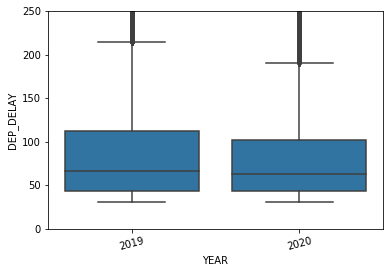

```python
base_color = sb.color_palette()[0]
sb.boxplot(data = flights[flights['DEP_DELAY'] >= 30], x = 'YEAR', y = 'DEP_DELAY', color = base_color)
plt.xticks(rotation = 15);
plt.ylim(0, 250)
```

Now what is interesting here is that even though the amount of total delayed minutes is way down, the distribution is looking closer to the same. There were many instances of outliers past 250 but in relation to the amount of observations, it is a small number. To make the plot more readable, the limit was set to 250. Even with this zoom in on the boxes, the distribution appears similar.

Let's take a look at the Security Delay anomaly.

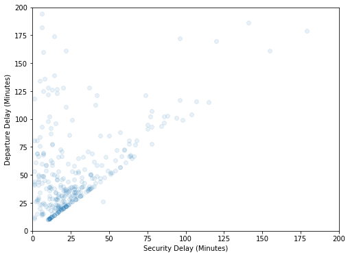

```python
plt.figure(figsize = [8, 6])
plt.scatter(data = flights[(flights['DEP_DELAY'] >= 10) & (flights['SECURITY_DELAY'] >= 1)], x = 'SECURITY_DELAY', y = 'DEP_DELAY', alpha = 1/10);
plt.ylim(0, 200)
plt.xlim(0, 200)
plt.xlabel('Security Delay (Minutes)')
plt.ylabel('Departure Delay (Minutes)');
```

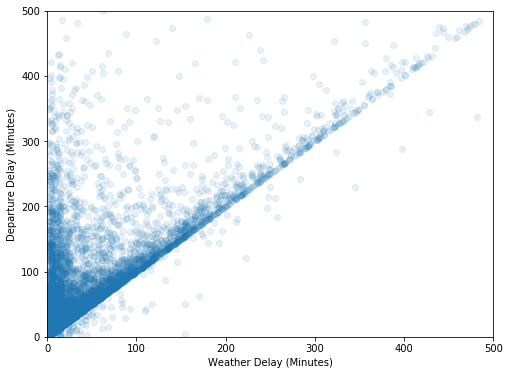

```python
plt.figure(figsize = [8, 6])
plt.scatter(data = flights[(flights['DEP_DELAY'] >= 1) & (flights['WEATHER_DELAY'] >= 1)], x = 'WEATHER_DELAY', y = 'DEP_DELAY', alpha = 1/10);
plt.ylim(0, 500)
plt.xlim(0, 500)
plt.xlabel('Weather Delay (Minutes)')
plt.ylabel('Departure Delay (Minutes)');
```

Here we have 2 scatter plots comparing security delay to departure delay, as well as weather delay to departure delay. There are just more instance of weather delays and they have a greater impact in magnitude and therefore have a stronger corelation with departure delay. Security delay has less defined line moving to the top right and many instances where its delay did not matter much to the over all departure delay. This can be seen in the vertical portion of its distribution.

### Talk about some of the relationships you observed in this part of the investigation. How did the feature(s) of interest vary with other features in the dataset?

Overall we see once again a large decrease in overall flights across the board, but this time we see some more detail of this effect. Some states like Hawaii, New York, and NJ had incredibly big drops in departing flights.

We also saw a huge decrease in the total amount of delay minutes from late departures, but interestingly, the distribution stayed roughly the same, just the instances decreased.

### Did you observe any interesting relationships between the other features (not the main feature(s) of interest)?

Out of all the delay categories, Security Delay's seem to not have any correlated affect on delays, positive or negative. This seems odd but it would appear there are just not many security delays and when it does happen it only adds a small amount of time.

## Multivariate Exploration

In the last section we found that there was a large decrease in total departure delay minutes between April 2019 and April 2020. Let's take another look for a specific busy airport. Let's check San Francisco's SFO.

```python
#proportion of April 2020 flights divided by April 2019 flights
np.round(apr20[apr20.ORIGIN == 'SFO'].count()[0]/apr19[apr19.ORIGIN == 'SFO'].count()[0],2)
```

```
0.33
```

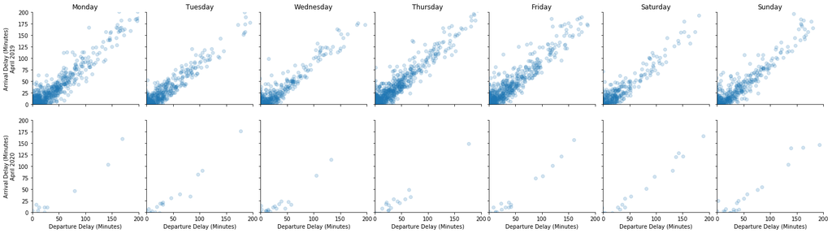

```python
#Faceted Grid of scatter plots for SFO and Day's of the week.
g = sb.FacetGrid(data = flights[flights.ORIGIN == 'SFO'], col = 'DAY_OF_WEEK', row = 'YEAR')
g.map(plt.scatter, 'DEP_DELAY', 'ARR_DELAY', alpha = .2)

axes = g.axes.flatten()

axes[0].set_title("Monday")
axes[1].set_title("Tuesday")
axes[2].set_title("Wednesday")
axes[3].set_title("Thursday")
axes[4].set_title("Friday")
axes[5].set_title("Saturday")
axes[6].set_title("Sunday")

for ax in range(len(axes)):
    if ax > 6:
        axes[ax].set_title("")
        axes[ax].set_xlabel("Departure Delay (Minutes)")

axes[0].set_ylabel("Arrival Delay (Minutes)\nApril 2019")
axes[7].set_ylabel("Arrival Delay (Minutes)\nApril 2020")


plt.xlim(0, 200)
plt.ylim(0, 200);
```

Here we are looking at the relationship between arrival and departure delay depending on each day of the week for flights departing from San Francisco (SFO). Each row represents the data from April 2019 and April 2020 respectively. The ranges have been limited to 200 minutes for ease of viewing.

The most notable difference is the almost absence of data in 2020. We saw earlier that there was a drop in total flight counts and for SFO in particular April 2020 was only 33% of the volume of the previous year. Would we expect to see around 30% of the density from the first row in the second row? As I predicted earlier, an ease on the airline system in general may allow it to operate more efficiently preventing delays.

Along with delays being less, does a less crowded runway mean shorter time preparing for take off? Let's use `TAXI_IN` and `TAXI_OUT`

```python
#get top 5 states by total number of flights
#this is for cleaner graphs
top5 = []
statesOrdered = flights.ORIGIN_STATE_ABR.value_counts().index.tolist()
for x in range(len(statesOrdered)):
    if x > 4:
        break
    top5.append(statesOrdered[x])


flights_top5 = flights[flights.ORIGIN_STATE_ABR.isin(top5)]
flights_top5 = flights_top5[flights_top5.TAXI_IN.notnull()]

#correct categorical data type
#to prevent filtered states from plotting
ordered_states = pd.api.types.CategoricalDtype(ordered = True, categories = top5)
flights_top5['ORIGIN_STATE_ABR'] = flights_top5['ORIGIN_STATE_ABR'].astype(ordered_states)
```

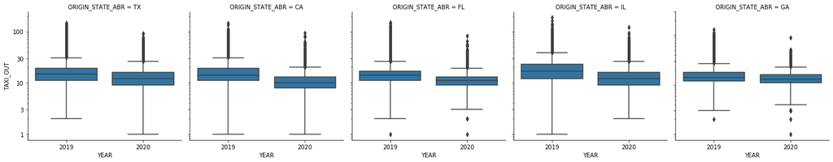

```python
#plots

g = sb.FacetGrid(data = flights_top5, col = 'ORIGIN_STATE_ABR', size = 4)
g.map(sb.boxplot, 'YEAR', 'TAXI_OUT')
ticks  = [1,3,10,30,100,300]
labels = ['{}'.format(v) for v in ticks]
plt.yscale('log')
plt.yticks(ticks, labels);
```

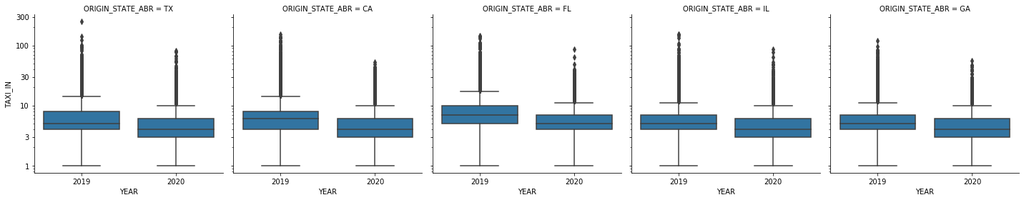

```python
g = sb.FacetGrid(data = flights_top5, col = 'ORIGIN_STATE_ABR', size = 4)
g.map(sb.boxplot, 'YEAR', 'TAXI_IN')
ticks  = [1,3,10,30,100,300]
labels = ['{}'.format(v) for v in ticks]
plt.yscale('log')
plt.yticks(ticks, labels);
```

These two sets of Box Plots show the amount of Taxi in and out minutes for the top 5 states in terms of number of total flights. We can see a dip in the median for all these states across both years which suggests that again because of the lack of traffic, there is less down time and delays found in general flight operation. This can most likely be explained by less time waiting for a slot on the runway or a gate to open due to congestion.

Be Aware that these plots are on a logarithmic scale for the taxi minutes.

### Talk about some of the relationships you observed in this part of the investigation. Were there features that strengthened each other in terms of looking at your feature(s) of interest?

Our primary concern was seeing the effect Coronovirus had on flights during the Month of April. We saw there was a overall decrease in terms of Departure delay minutes as well as time for planes to taxi to and from the runway. Our data confirms that delays are less of a problem during this time when compared to April 2019 which was fairly normal operation.

### Were there any interesting or surprising interactions between features?

Nothing too surprising. These relationships were in line with initial expectations.